# Seurat HBCA Workshop

```r
# Load package libraries
library(dplyr)
library(Seurat)
library(patchwork)
library(celldex)

# Set seed for reproducibility
set.seed(25)
```

## Step 1. Create a Seurat object

Seurat implements a new data type which is named ‘Seurat’. It allows Seurat to store all the steps and results along the whole analysis. Therefore, the first step is to read in the data and create a Seurat object. Seurat has an easy solution for data generated using the 10x Genomics platform. What the Read10X function does is to read in the matrix and rename its row names and col names by gene symbols and cell barcodes, respectively. Alternatively, one can do this manually, which is probably what one would do when the data is not generated using 10x.

#### You will need to download the `HBCA_85` data directory [here](https://www.dropbox.com/scl/fo/92mtyq9phaf13kigz5wcg/AF3dseRvlbcpLGsS7CMGRDQ?rlkey=6k59eiy8hw1ydmhwyfm58z69o&dl=0) before running the below code.

```r
hbca.data <- Read10X(data.dir = "HBCA_85")
# - 'counts': the gene expression matrix
# - 'project': project name label
# - 'min.cells = 3': keep genes detected in ≥ 3 cells
# - 'min.features = 200': keep cells with ≥ 200 detected genes
hbca <- CreateSeuratObject(counts = hbca.data, project = "hbca3k", min.cells = 3, min.features = 200)
# View the Seurat object summary
hbca
```

```
## An object of class Seurat
## 23066 features across 13235 samples within 1 assay
## Active assay: RNA (23066 features, 0 variable features)
##  1 layer present: counts
```

```r
# Preview the raw expression data for specific genes
# This shows expression values of COL1A1, JCHAIN, and LUM in the first 30 cells
hbca.data[c("COL1A1", "JCHAIN", "LUM"), 1:30]
```

```
## 3 x 30 sparse Matrix of class "dgCMatrix"
```

```
##
## COL1A1 . .   1 . 1 3 3 50 . . . . . . 1 . 151 . 2 7 5 . . . . . . . .  .
## JCHAIN 2 . 194 . . . .  2 . . . . . . . .   . 1 . . 1 . . 1 . . . . 1  .
## LUM    9 .   1 . 2 . .  6 . . . . . . . .  15 . 2 7 7 2 . . . . . . . 18
```

## Step 2. Quality control

After creating the Seurat object, the next step is to do quality control on the data. The most common quality control is to filter out Cells with too few genes detected. They usually represent cells which are not sequenced deep enough for reliable characterization. Cells with too many genes detected. They may represent doublets or multiplets (i.e. two or more cells in the same droplet, therefore sharing the same cell barcode). Cells with high mitochondrial transcript percentage. As most of the scRNA-seq experiments use oligo-T to capture mRNAs, mitochondrial transcripts should be relatively under-representative due to their lack of poly-A tails, but it is unavoidable that some mitochondrial transcripts are captured. Meanwhile, there is also some evidence that stable poly-A tails exist in some mitochondrial transcripts but serve as a marker for degradation (e.g. this paper). Together, cells with high mitochondrial transcript percentage likely represent cells under stress (e.g. hypoxia) which produce a lot of mitochondria, or which produce an abnormally high amount of truncated mitochondrial transcripts. While numbers of detected genes are summarized by Seurat automatically when creating the Seurat object (with nFeature_RNA being the number of detected genes/features; nCount_RNA being the number of detected transcripts), one needs to calculate mitochondial transcript percentages manually. Still, Seurat provides an easy solution

```r
#Add mitochondrial gene content (% of reads mapping to mitochondrial genes)
# - Looks for gene names starting with "MT-" (human mitochondrial genes)
hbca[["percent.mt"]] <- PercentageFeatureSet(hbca, pattern = "^MT-")

# Show the first few rows of the metadata table (one row per cell)
head(hbca@meta.data, 5)
```

|  | orig.ident | nCount_RNA | nFeature_RNA | percent.mt |
| --- | --- | --- | --- | --- |
| AAACCCAAGGTCGACA-1 | hbca3k | 3887 | 1276 | 8.592745 |
| AAACCCAAGTTGCTGT-1 | hbca3k | 11200 | 2737 | 15.053571 |
| AAACCCACAAAGGCAC-1 | hbca3k | 16307 | 1776 | 2.851536 |
| AAACCCACACTACCGG-1 | hbca3k | 2549 | 958 | 9.729306 |
| AAACCCAGTCATTGCA-1 | hbca3k | 709 | 453 | 2.679831 |

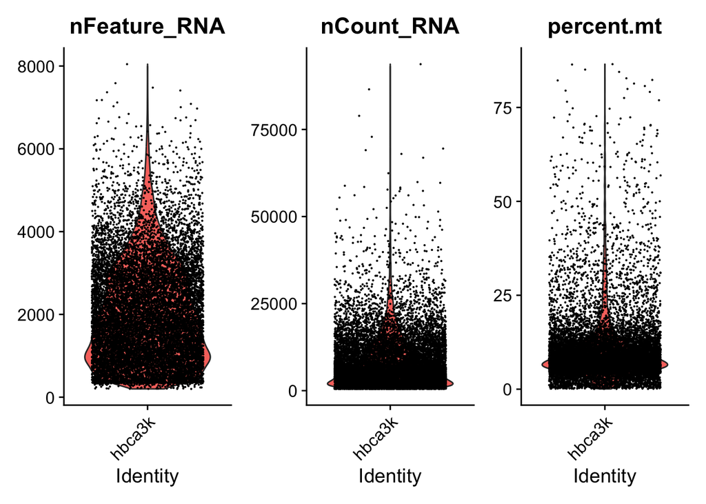

```r
# Visualize quality control metrics with violin plots
VlnPlot(hbca, features = c("nFeature_RNA", "nCount_RNA", "percent.mt"), ncol = 3)
```

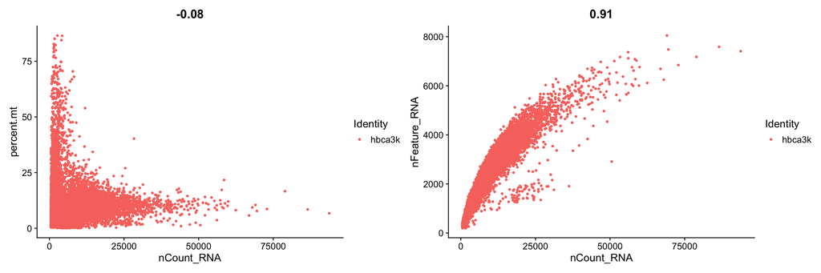

```r
# FeatureScatter is typically used to visualize feature-feature relationships, but can be used
# for anything calculated by the object, i.e. columns in object metadata, PC scores etc.
plot1 <- FeatureScatter(hbca, feature1 = "nCount_RNA", feature2 = "percent.mt")
plot2 <- FeatureScatter(hbca, feature1 = "nCount_RNA", feature2 = "nFeature_RNA")
plot1 + plot2
```

Please note that there is no one-size-fits-all filtering criteria, as the normal ranges of these metrics can vary dramatically from one experiment to another, depending on sample origin as well as reagents and sequencing depths. One suggestion here is to ONLY FILTER OUT OUTLIER CELLS, i.e. the minority of cells with certain QC metrics clearly above or below the majority of cells. To do that, one needs to first know how these values are distributed in the data. One can look at the distribution by creating a violin plot for each of the metrics.

```r
#filter data by mitochondrial gene counts
hbca <- subset(hbca, subset = nFeature_RNA > 200 & nFeature_RNA < 5000 & percent.mt < 20)
```